# Publications

[Google Scholar Profile](https://scholar.google.com/citations?user=CkjjlnwAAAAJ&hl=en&oi=ao)

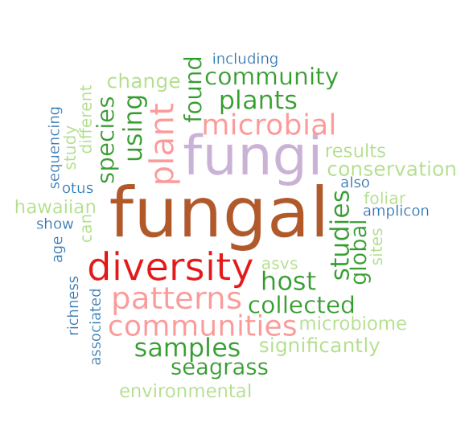

† Denotes student mentee

**Miller, I. P., Laney, A. G., Zahn, G., Sheehan, B. J., Whitley, K. V., & Kuddus, R. H. (2024). Isolation and preliminary characterization of a novel bacteriophage vB_KquU_φKuK6 that infects the multidrug-resistant pathogen Klebsiella quasipneumoniae. Frontiers in Microbiology, 15. https://doi.org/10.3389/fmicb.2024.1472729**

I don’t know much about phages, but I can assemble and annotate genomes like a champ…so I did. This particular phage has theraputic potential against *Klebsiella quasipneumoniae*, which is cool!

**Wainwright, B. J., Leon, J.†, Vilela, E.†, Hickman, K. J. E.†, Caldwell, J.†, Aimone, B.†, Bischoff, P.†, Ohran, M.†, Morelli, M. W.†, Arlyza, I. S., Marwayana, O. N., & Zahn, G. (2024). Wallace’s line structures seagrass microbiota and is a potential barrier to the dispersal of marine bacteria. Environmental Microbiome. https://doi.org/10.1186/s40793-024-00568-3**

Cryptic dispersal barriers can affect bacterial assemblages in seagrasses. Wallace’s Line, separates distinct bacterial community structures in the Indonesian Archipelago. Since cryptic dispersal barriers exist for bacteria in this region, this may have implications for the biogeography of macroorganisms that depend on these microbes.

**Hickman, K. J. E.†, & Zahn, G. (2024) Ten simple rules for leading a successful undergraduate-intensive research lab. PLOS Computational Biology. https://doi.org/10.1371/journal.pcbi.1011994**

A student and a PI share some wisdom about how to run a killer undergrad-focused research lab.

**Mikryukov, V., Dulya, O., Zizka, A., Bahram, M., Hagh-Doust, N., Anslan, S., Prylutskyi, O., Delgado-Baquerizo, M., Maestre, F. T., Nilsson, H., Pärn, J., Öpik, M., Moora, M., Zobel, M., Espenberg, M., Mander, Ü., Khalid, A. N., Corrales, A., Agan, A., … Zahn, G., … Tedersoo, L. (2023). Connecting the multiple dimensions of global soil fungal diversity. Science Advances, 9(48), eadj8016. https://doi.org/10.1126/sciadv.adj8016**

Precipitation and temperature drive fungal compositional turnover (beta diversity) and phylogenetic diversity, linking them with regional species richness (gamma diversity).

**Wainwright, B. J., Millar, T.†, Bowen, L.†, Semon, L.†, Hickman, K. J. E.†, Lee, J. N., Yeo, Z. Y., & Zahn, G. (2023). The core mangrove microbiome reveals shared taxa potentially involved in nutrient cycling and promoting host survival. Environmental Microbiome, 18(1), 47. https://doi.org/10.1186/s40793-023-00499-5**

Environmental filtering is occurring in mangrove microbiomes, with hosts selecting for a microbial consortia most suitable for survival in their immediate environment

**Rawson, C.†, & Zahn, G. (2023). Inclusion of database outgroups reduces false positives in fungal metabarcoding taxonomic assignments. Mycologia. https://doi.org/10.1080/00275514.2023.2206931**

Assigning taxonomy to fungal amplicons against a fungal-only database WILL lead to false inflation of fungal diversity. Use a database with eukaryotic outgroups like the UNITE_All database.

**Watmough, S., Gilbert-Parkes, S., Basiliko, N., Lamit, L. J., Lilleskov, E. A., Andersen, R., … Zahn, G. (2022). Variation in carbon and nitrogen concentrations among peatland categories at the global scale. PLOS ONE, 17(11), e0275149. https://doi.org/10.1371/journal.pone.0275149**

Global-scale survey of peatland C and N reveals that broadly classified peatland categories have predictable C and OM concentrations. This adds needed resolution to climate models using land cover assessment for global C and N stocks.

**McGee, S.†, Tidwell, A.†, Riggs, E., Veltkamp, H.†, & Zahn, G. (2022). Long-term soil fungal community recovery after fire is impacted by climate change. Western North American Naturalist, 82(3). https://scholarsarchive.byu.edu/wnan/vol82/iss3/3**

Soil fungi take a really really long time to bounce back after a forest fire, but warmer soil speeds up the process.

**Tedersoo, L., Mikryukov, V., Zizka, A., Bahram, M., Hagh-Doust, N., Anslan, S., Prylutskyi, O., Delgado-Baquerizo, M., Maestre, F. T., Pärn, J., Öpik, M., Moora, M., Zobel, M., Espenberg, M., Mander, Ü., Khalid, A. N., Corrales, A., Agan, A., Vasco-Palacios, A.-M., … Abarenkov, K. (2022). Global patterns in endemicity and vulnerability of soil fungi. Global Change Biology, n/a(n/a). https://doi.org/10.1111/gcb.16398**

**Zahn, G. (2022). Marker Genes (16S and ITS) Protocol for Plant Microbiome Analyses. BIO-PROTOCOL, 12(8). https://doi.org/10.21769/BioProtoc.4395**

A recipe, with code and instructions on how to turn raw meta-amplicon reads into insights without leaving R.

**Tedersoo, L., Mikryukov, V., Anslan, S., Bahram, M., Khalid, A. N., Corrales, A., Agan, A., Vasco-Palacios, A.-M., Saitta, A., Antonelli, A., Rinaldi, A. C., Verbeken, A., Sulistyo, B. P., Tamgnoue, B., Furneaux, B., Ritter, C. D., Nyamukondiwa, C., Sharp, C., Marín, C., … Zahn, G., … Abarenkov, K. (2021). The Global Soil Mycobiome consortium dataset for boosting fungal diversity research. Fungal Diversity. https://doi.org/10.1007/s13225-021-00493-7**

An 11-year global soil fungi sampling effort published as a publicly open dataset. The dataset comprises 722,682 fungal operational taxonomic units (OTUs) derived from PacBio sequencing of full-length ITS and 18S-V9 variable regions from 3200 plots in 108 countries on all continents.

**Sur, G. L., Zahn, G., & Stacy, E. A. (2021). Examination of host-taxon, environment, and distance effects on leaf fungal endophytes in the dominant woody genus, Metrosideros, on Oʻahu. Fungal Ecology, 53, 101093. https://doi.org/10.1016/j.funeco.2021.101093**

We examined the relative importance of Metrosideros taxon and environment (elevation) on fungal endophyte (FE) communities on Oʻahu. Variation in FE diversity was significantly explained by host taxon and site with considerable overlap in FE communities among taxa. A significant pattern of isolation by distance in FE composition was detected both among and within sites, consistent with restricted dispersal of FEs across the island. ___

**Quek, Z. B. R., Zahn, G., Lee, N. L. Y., Ooi, J. L. S., Lee, J. N., Huang, D., & Wainwright, B. J. (2021). Biogeographic structure of fungal communities in seagrass Halophilia ovalis across the Malay Peninsula. Environmental Microbiology Reports. https://doi.org/10.1111/1758-2229.13003**

Seagrass meadows globally are under severe duress due to both climate change and anthropogenic activities. We looked to see where seagrasses are acquiring their mycobiomes and conclude that transplantation/restoration efforts need to consider the geographic location of donor populations with regard to beneficial mycobiomes.

**Egan, C. P., Koko, J. H., Muir, C. D., Zahn, G., Swift, S. O. I., Amend, A. S., & Hynson, N. A. (2021). Restoration of the mycobiome of the endangered Hawaiian mint Phyllostegia kaalaensis increases its resistance to a common powdery mildew. Fungal Ecology, 52, 101070. https://doi.org/10.1016/j.funeco.2021.101070**

Restoring a beneficial foliar mycobiome turns out to be more effective than restoring rhizosphere mycobiome for protecting an endangered plant from powdery mildew. This is an effective and easy treatment for plant conservation efforts.

**Tipton, L., Zahn, G. L., Darcy, J. L., Amend, A. S., & Hynson, N. A. (2021). Hawaiian Fungal Amplicon Sequence Variants Reveal Otherwise Hidden Biogeography. Microbial Ecology. https://doi.org/10.1007/s00248-021-01730-x**

Using exact sequence variants instead of clustered OTUs improves reproducibility, eases meta-analyses, and can reveal otherwise hidden biogeographic patterns in environmental DNA studies of fungal distributions.

**Wainwright, B. J., Zahn, G. L., Afiq-Rosli, L., Tanzil, J. T. I., & Huang, D. (2020). Host age is not a consistent predictor of microbial diversity in the coral Porites lutea. Scientific Reports, 10(1), 14376. https://doi.org/10.1038/s41598-020-71117-4**

When corals are aged with more-accurate methods it appears that increased age doesn’t necessarily mean greater microbiome diversity, at least for this coral species. Environmental conditions were more important. This contrasts with previous work that used coral age estimations, rather than direct measurements of age using skeletal banding.

**Darcy J L, Swift S, Cobian G M, Zahn G, Perry B A, Amend A.. 2020. Fungal communities living within leaves of native Hawaiian dicots are structured by landscape-scale variables as well as by host plants. Molecular Ecology. https://doi.org/10.1111/mec.15544**

Landscape-scale variation in plant phylogeny, NDVI, elevation, evapotranspiration, etc., show how the interaction of factors at large and small spatial and phylogenetic scales shape fungal symbiont communities.

**Tipton*, L., Zahn*, G., Datlof, E.†, Kivlin, S. N., Sheridan, P., Amend, A. S., & Hynson, N. A.. 2019. Fungal aerobiota are not affected by time nor environment over a 13-y time series at the Mauna Loa Observatory. Proceedings of the National Academy of Sciences. https://doi.org/10.1073/pnas.1907414116**

Upper-atmosphere fungal assemblages are stochastic over a decadal scale. Seriously *nothing* seems to affect them deterministically.

*These authors contributed equally to this work

**Benjamin J. Wainwright, Geoffrey L. Zahn, Joshua Zushi†, Nicole Li Ying Lee, Jillian Lean Sim Ooi, Jen Nie Lee, Danwei Huang. 2019. Seagrass-associated fungal communities show distance decay of similarity that has implications for seagrass management and restoration. Ecology and Evolution. https://doi.org/10.1002/ece3.5631**

Even with few presumed barriers to dispersal, seagrass-associated fungal communities appear to be structured by location.

**Wainwright, B. J., Bauman, A. G., Zahn, G. L., Todd, P. A., & Huang, D. 2019. Characterization of fungal biodiversity and communities associated with the reef macroalga Sargassum ilicifolium reveals fungal community differentiation according to geographic locality and algal structure. Marine Biodiversity. https://doi.org/10.1007/s12526-019-00992-6**

Fungal community structure varies between macroalga structures, but the majority of fungi amplified were not classifiable. This highlights the need to better explore and catalog the diversity of marine fungi.

**BJ Wainwright, L Afiq-Rosli, GL Zahn, D Huang. 2019. Characterisation of coral-associated bacterial communities in an urbanised marine environment shows strong divergence over small geographic scales. Coral Reefs, 1-10. https://doi.org/10.1007/s00338-019-01837-1**

Even in a geographically small area (Singapore), coral bacteria were different on windward and leeward sides of islands. This may need to be kept in mind when designing coral recovery strategies.i

**G Zahn, AS Amend. 2019. Foliar fungi alter reproductive timing and allocation in Arabidopsis under normal and water-stressed conditions. Fungal Ecology 41, 101-106. https://doi.org/10.1016/j.funeco.2019.04.002**

What we think of as “plant” traits, may actually be microbial traits in disguise. Here, fungal endophytes, regardless of identity, increased flowering time and seed mass in Arabidopsis thalliana.

**Wainwright BJ., Zahn GL., Arlyza IS., Amend AS. 2018. Seagrass-associated fungal communities follow Wallace’s line, but host genotype does not structure fungal community. Journal of Biogeography:n/a-n/a. https://doi.org/10.1111/jbi.13168.**

Fungi associated with the seagrass Syringodium isoetifolium had different community structure on either side of Wallace’s Line, a theoretical boundary that separates Asian and Australasian flora and fauna. This suggests that whatever processes enforce this “boundary” in macro organisms may be at work at the microbial scale as well.

**Zahn G., Amend AS. 2017. Foliar microbiome transplants confer disease resistance in a critically-endangered plant. PeerJ 5:e4020. DOI: 10.7717/peerj.4020. https://peerj.com/articles/4020/**

A conservation story with a happy ending: A simple, low-tech method of transplanting endophytic fungi from healthy relatives strongly reduced disease mortality and increased out-planting success of the endangered endemic Hawaiian mint, Phyllostegia kaalaensis. Plant conservation efforts can be greatly improved by considering plant microbiomes. Read more here: https://www.sciencenews.org/article/plant-microbes-crops-food-endangered-species

**Datlof EM, Amend AS, Earl K, Hayward J, Morden CW, Wade R, Zahn G, Hynson NA. (2017) Uncovering unseen fungal diversity from plant DNA banks. PeerJ 5:e3730 https://doi.org/10.7717/peerj.3730**

DNA banks house a wealth of genetic information, even for endangered and extinct plants. But they also hold information about the microbes present when the DNA was collected. They can be harnessed to ask historical questions about plant-microbe symbioses.

**Wainwright BJ, Zahn GL, Spalding HL, Sherwood AR, Smith CM, Amend AS. (2017) Fungi associated with mesophotic macroalgae from the ’Au‘au Channel, west Maui are differentiated by host and overlap terrestrial communities. PeerJ 5:e3532 https://doi.org/10.7717/peerj.3532**

Even 100m below the surface of the ocean, in the mesophotic zone, fungi are associating with algae. Roughly a third of the fungi recovered were also found in nearby terrestrial plants, showing the potential for wide host ranges. This unexplored ecosystem should be considered when estimating global fungal biodiversity.

**Geoffrey Zahn, Rota Wagai, Seiichiro Yonemura. 2016. The effects of amoebal bacterivory on carbon and nitrogen dynamics depend on temperature and soil structure interactions. Soil Biology and Biochemistry, 94:133-137. https://doi.org/10.1016/j.soilbio.2015.11.021**

Amoebae in soils are some of the top bacterial predators, and they are responsible for helping determine C and N turnover rates. But with global warming and changes to agricultural management practices, the effect of amoebal bacterivory is altered. Soil carbon models (Q10) should incorporate food web dynamics to increase accuracy.

**Geoffrey Zahn, Steven L. Stephenson, Frederick W. Spiegel. 2014. Ecological distribution of protosteloid amoebae in New Zealand. PeerJ 2:e296; https://doi.org/10.7717/peerj.296**

In a thorough survey of New Zealand, we detected broad environmental influences on the distribution of 30 protosteloid amoebae. Latitude, precipitation, and elevation matter as limiters of distribution.

**Miriam De Haan, Christine Cocquyt, Alex Tice, Geoffrey Zahn, Frederick W. Spiegel. 2014. First records of Protosteloid Amoebae (Eumycetozoa) from the Democratic Republic of the Congo. Plant Ecology and Evolution, 147:1, 85-92; https://doi.org/10.5091/plecevo.2014.883**

The high species diversity observed on a limited number of samples suggests that the DRC region is, together with Hawai’i, one of the world’s tropical hotspots for protosteloid amoeba diversity.

**Erin R. Murphy, Jacob Boxberger, Robert Colvin, Suk Je Lee, Geoffrey Zahn, Fred Loor, Kyoungtae Kim. 2011. Pil1, an eisosome organizer, plays an important role in the recruitment of synaptojanins and amphiphysins to facilitate receptor-mediated endocytosis in yeast. European Journal of Cell Biology, 90:10, 825-833. https://doi.org/10.1016/j.ejcb.2011.06.006**

The title says it all.